# Health-System Specialty Pharmacies Ensure Patients Initiate New Oncology Treatments: A Multisite Study

# 1 Study overview

## 1.1 Background

There is limited literature describing the rate of PMN for prescribed specialty oncology oral medications, though some have estimated 9-10% of patients do not obtain prescribed oral oncology medications.1, 2 Patients prescribed oncology specialty medications face unique potential barriers to obtaining and initiating treatment including high cost, specialty pharmacy limitations, and strict insurance requirements.3 Understanding PMN rates for oncology specialty therapies is the first step to addressing barriers to fulfillment and improving clinical outcomes. Health-systems specialty pharmacies provide significant medication access support to reduce financial burden and streamline patient access to therapy in a timely manner.

## 1.2 Methods

This will be a multisite, retrospective, cohort study of patients with a specialty oncology medication referral to one of the health-system specialty pharmacies. Sites will perform PMN analysis at their institution.

**Patient population:**

- Patients will be considered for inclusion if they have a referral for an included oncology medication generated within health-system and sent to health-system specialty pharmacy between May 1st, 2020 through July 31st, 2020. A referral will include a prescription sent to the specialty pharmacy or a communication from a prescriber to a pharmacy team member recommending treatment initiation.
- Patients will be excluded if the medication is prescribed by a non-health system provider or non-oncology provider or for non-oncology disease.

## 1.3 Outcomes

- Rate of primary medication non-adherence (PMN)
- Reasons for PMN

# 2 Exclusions

Patients are excluded from the study if after exclusion on review they were found to be already on treatment (not naive) or if they are receiving medication for non-hematology or oncology reasons. There were a total of 993 referrals that initially met inclusion criteria.

| **Characteristic** | **N** | **N = 993**<sup>1</sup> |
| --- | --- | --- |
| Excluded | 993 |  |
| Additional review needed |  | 515 (51.9%) |
| Already on treatment, not naive |  | 33 (3.32%) |
| Filled outside fill window |  | 13 (1.31%) |
| No exclusion criteria identified |  | 419 (42.2%) |
| Non-hematology or oncology provider/indication |  | 13 (1.31%) |
| PMN eligible | 993 |  |
| No |  | 46 (4.63%) |
| Yes |  | 947 (95.4%) |

<sup>1</sup> n (%)

# 3 Descriptive statistics

## 3.1 Demographics

| **Characteristic** | **N** | **Site 1**, N = 233<sup>1</sup> | **Site 2**, N = 102<sup>1</sup> | **Site 3**, N = 333<sup>1</sup> | **Site 4**, N = 64<sup>1</sup> | **Site 5**, N = 29<sup>1</sup> | **Site 6**, N = 76<sup>1</sup> | **Site 7**, N = 110<sup>1</sup> | **p-value**<sup>2</sup> | **Overall**, N = 947<sup>1</sup> |
| --- | --- | --- | --- | --- | --- | --- | --- | --- | --- | --- |
| age | 947 |  |  |  |  |  |  |  | 0.10 |  |
| Mean (SD) |  | 62.3 (13.4) | 63.4 (14.5) | 62.8 (15.6) | 60.3 (12.9) | 59.9 (12.4) | 66.0 (14.0) | 62.3 (14.4) |  | 62.7 (14.4) |
| Median (IQR) |  | 65.0 (55.0 - 71.0) | 66.0 (57.2 - 72.8) | 65.0 (54.0 - 73.0) | 62.0 (54.8 - 68.0) | 60.0 (55.0 - 69.0) | 69.0 (57.8 - 74.0) | 65.0 (54.0 - 71.0) |  | 65.0 (55.0 - 73.0) |
| Range |  | 15.0 - 87.0 | 20.0 - 88.0 | 12.0 - 94.0 | 20.0 - 86.0 | 33.0 - 80.0 | 26.0 - 92.0 | 18.0 - 90.0 |  | 12.0 - 94.0 |
| Gender | 947 |  |  |  |  |  |  |  | 0.2 |  |
| Male |  | 122 (52.4%) | 52 (51.0%) | 188 (56.5%) | 36 (56.2%) | 15 (51.7%) | 40 (52.6%) | 45 (40.9%) |  | 498 (52.6%) |
| Female |  | 111 (47.6%) | 50 (49.0%) | 145 (43.5%) | 28 (43.8%) | 14 (48.3%) | 36 (47.4%) | 65 (59.1%) |  | 449 (47.4%) |
| Insurance type | 947 |  |  |  |  |  |  |  |  |  |
| Medicare |  | 103 (44.2%) | 61 (59.8%) | 162 (48.6%) | 19 (29.7%) | 10 (34.5%) | 47 (61.8%) | 49 (44.5%) |  | 451 (47.6%) |
| Medicaid |  | 18 (7.73%) | 19 (18.6%) | 35 (10.5%) | 24 (37.5%) | 5 (17.2%) | 10 (13.2%) | 6 (5.45%) |  | 117 (12.4%) |
| Tricare |  | 0 (0%) | 0 (0%) | 3 (0.90%) | 0 (0%) | 0 (0%) | 2 (2.63%) | 3 (2.73%) |  | 8 (0.84%) |
| Commercial |  | 104 (44.6%) | 20 (19.6%) | 124 (37.2%) | 19 (29.7%) | 14 (48.3%) | 15 (19.7%) | 42 (38.2%) |  | 338 (35.7%) |
| None |  | 8 (3.43%) | 2 (1.96%) | 9 (2.70%) | 2 (3.12%) | 0 (0%) | 2 (2.63%) | 0 (0%) |  | 23 (2.43%) |
| Other |  | 0 (0%) | 0 (0%) | 0 (0%) | 0 (0%) | 0 (0%) | 0 (0%) | 10 (9.09%) |  | 10 (1.06%) |
| Was the referral filled within the 30 day fill window? | 947 |  |  |  |  |  |  |  | <0.001 |  |
| NOT filled |  | 151 (64.8%) | 7 (6.86%) | 188 (56.5%) | 27 (42.2%) | 10 (34.5%) | 21 (27.6%) | 22 (20.0%) |  | 426 (45.0%) |
| Filled |  | 82 (35.2%) | 95 (93.1%) | 145 (43.5%) | 37 (57.8%) | 19 (65.5%) | 55 (72.4%) | 88 (80.0%) |  | 521 (55.0%) |

<sup>1</sup> n (%)  
<sup>2</sup> Kruskal-Wallis rank sum test; Pearson's Chi-squared test

## 3.2 Indications

| **Characteristic** | **N** | **N = 947**<sup>1</sup> |
| --- | --- | --- |
| Indications NCCN | 947 |  |
| Prostate |  | 134 (14.1%) |
| Breast |  | 106 (11.2%) |
| Central Nervous System |  | 78 (8.24%) |
| Lung (non-small cell, small cell) |  | 62 (6.55%) |
| Leukemia |  | 57 (6.02%) |
| Acute myeloid leukemia |  | 56 (5.91%) |
| Colon |  | 47 (4.96%) |
| Kidney |  | 44 (4.65%) |
| Hepatobiliary |  | 36 (3.80%) |
| Ovarian Fallopian tube/peritoneal |  | 33 (3.48%) |
| Chronic Myeloid Leukemia |  | 30 (3.17%) |
| Uterine |  | 27 (2.85%) |
| Rectal |  | 23 (2.43%) |
| Melanoma (skin) |  | 21 (2.22%) |
| Pancreatic adenocarcinoma |  | 21 (2.22%) |
| Soft tissue sarcoma |  | 21 (2.22%) |
| B-cell lymphoma |  | 19 (2.01%) |
| Multiple Myeloma |  | 18 (1.90%) |
| ALL |  | 17 (1.80%) |
| Tyroid |  | 17 (1.80%) |
| gastric |  | 11 (1.16%) |
| Esophageal and esophagogastric junction |  | 9 (0.95%) |
| Myelodysplastic Syndromes |  | 9 (0.95%) |
| Neuroendocrine and Adrenal |  | 9 (0.95%) |
| Bone |  | 8 (0.84%) |
| Hodgkin lymphoma |  | 8 (0.84%) |
| Anal |  | 4 (0.42%) |
| Bladder |  | 4 (0.42%) |
| Head and neck |  | 4 (0.42%) |
| T-cell lymphomas |  | 4 (0.42%) |
| small bowel |  | 3 (0.32%) |
| Systemic mastocystitis |  | 3 (0.32%) |
| Cervical |  | 1 (0.11%) |
| Mesothelioma |  | 1 (0.11%) |
| Testicular |  | 1 (0.11%) |
| Unknown |  | 1 (0.11%) |

<sup>1</sup> n (%)

## 3.3 Medications

### 3.3.1 Referred

| **Characteristic** | **N** | **N = 947**<sup>1</sup> |
| --- | --- | --- |
| Referred and filled medication match | 521 |  |
| Yes |  | 513 (98.5%) |
| No |  | 8 (1.54%) |
| Missing |  | 426 |
| Prescribed Medication Name Radio | 947 |  |
| capecitabine |  | 134 (14.1%) |
| temozolomide |  | 69 (7.29%) |
| venetoclax |  | 69 (7.29%) |
| abiraterone |  | 59 (6.23%) |
| ibrutinib |  | 43 (4.54%) |
| enzalutamide |  | 38 (4.01%) |
| olaparib |  | 35 (3.70%) |
| lenvatinib |  | 34 (3.59%) |
| palbociclib |  | 31 (3.27%) |
| everolimus |  | 26 (2.75%) |
| cabozanitinib |  | 25 (2.64%) |
| imatinib |  | 23 (2.43%) |
| osimertinib |  | 22 (2.32%) |
| dasatinib |  | 19 (2.01%) |
| alpelisib |  | 17 (1.80%) |
| apalutamide |  | 17 (1.80%) |
| axitinib |  | 17 (1.80%) |
| etoposide |  | 15 (1.58%) |
| pazopanib |  | 15 (1.58%) |
| acalabrutinib |  | 14 (1.48%) |
| regorafenib |  | 13 (1.37%) |
| dabrafenib |  | 11 (1.16%) |
| ixazomib |  | 11 (1.16%) |
| sorafenib |  | 11 (1.16%) |
| Cyclophosphamide |  | 10 (1.06%) |
| trifluridine/tipiracil |  | 10 (1.06%) |
| lomustine |  | 9 (0.95%) |
| selpercatinib |  | 9 (0.95%) |
| abemaciclib |  | 8 (0.84%) |
| erdafitinib |  | 8 (0.84%) |
| niraparib |  | 8 (0.84%) |
| enasidenib |  | 7 (0.74%) |
| lenalidomide |  | 7 (0.74%) |
| midostaurin |  | 7 (0.74%) |
| nilotinib |  | 7 (0.74%) |
| rucaparib |  | 7 (0.74%) |
| afatinib |  | 6 (0.63%) |
| bosutinib |  | 6 (0.63%) |
| darolutamide |  | 6 (0.63%) |
| trametinib |  | 6 (0.63%) |
| alectinib |  | 5 (0.53%) |
| capmatinib |  | 5 (0.53%) |
| tucatinib |  | 5 (0.53%) |
| binimetinib |  | 4 (0.42%) |
| gilteritinib |  | 4 (0.42%) |
| ribociclib |  | 4 (0.42%) |
| selumetinib |  | 4 (0.42%) |
| sunitinib |  | 4 (0.42%) |
| pomalidomide |  | 3 (0.32%) |
| vemurafenib |  | 3 (0.32%) |
| crizotinib |  | 2 (0.21%) |
| erlotinib |  | 2 (0.21%) |
| ivosidenib |  | 2 (0.21%) |
| loralatinib |  | 2 (0.21%) |
| melphalan |  | 2 (0.21%) |
| selinexor |  | 2 (0.21%) |
| gefitinib |  | 1 (0.11%) |
| idelalisib |  | 1 (0.11%) |
| ponatinib |  | 1 (0.11%) |
| thalidomide |  | 1 (0.11%) |
| zanubrutinib |  | 1 (0.11%) |

<sup>1</sup> n (%)

### 3.3.2 Filled

| **Characteristic** | **N** | **N = 521**<sup>1</sup> |
| --- | --- | --- |
| Referred and filled medication match | 521 |  |
| Yes |  | 513 (98.5%) |
| No |  | 8 (1.54%) |
| Name of Medication Filled Radio | 521 |  |
| capecitabine |  | 82 (15.7%) |
| venetoclax |  | 46 (8.83%) |
| temozolomide |  | 41 (7.87%) |
| ibrutinib |  | 36 (6.91%) |
| abiraterone |  | 32 (6.14%) |
| lenvatinib |  | 19 (3.65%) |
| enzalutamide |  | 17 (3.26%) |
| palbociclib |  | 17 (3.26%) |
| imatinib |  | 15 (2.88%) |
| cabozanitinib |  | 13 (2.50%) |
| etoposide |  | 13 (2.50%) |
| olaparib |  | 13 (2.50%) |
| everolimus |  | 12 (2.30%) |
| pazopanib |  | 10 (1.92%) |
| apalutamide |  | 9 (1.73%) |
| axitinib |  | 9 (1.73%) |
| acalabrutinib |  | 8 (1.54%) |
| alpelisib |  | 8 (1.54%) |
| regorafenib |  | 8 (1.54%) |
| Cyclophosphamide |  | 7 (1.34%) |
| dasatinib |  | 6 (1.15%) |
| osimertinib |  | 6 (1.15%) |
| trifluridine/tipiracil |  | 6 (1.15%) |
| afatinib |  | 5 (0.96%) |
| ixazomib |  | 5 (0.96%) |
| lenalidomide |  | 5 (0.96%) |
| niraparib |  | 5 (0.96%) |
| sorafenib |  | 5 (0.96%) |
| abemaciclib |  | 4 (0.77%) |
| gilteritinib |  | 4 (0.77%) |
| nilotinib |  | 4 (0.77%) |
| tucatinib |  | 4 (0.77%) |
| binimetinib |  | 3 (0.58%) |
| capmatinib |  | 3 (0.58%) |
| lomustine |  | 3 (0.58%) |
| ribociclib |  | 3 (0.58%) |
| selpercatinib |  | 3 (0.58%) |
| selumetinib |  | 3 (0.58%) |
| alectinib |  | 2 (0.38%) |
| bosutinib |  | 2 (0.38%) |
| dabrafenib |  | 2 (0.38%) |
| darolutamide |  | 2 (0.38%) |
| enasidenib |  | 2 (0.38%) |
| melphalan |  | 2 (0.38%) |
| midostaurin |  | 2 (0.38%) |
| pomalidomide |  | 2 (0.38%) |
| rucaparib |  | 2 (0.38%) |
| selinexor |  | 2 (0.38%) |
| sunitinib |  | 2 (0.38%) |
| trametinib |  | 2 (0.38%) |
| gefitinib |  | 1 (0.19%) |
| loralatinib |  | 1 (0.19%) |
| ponatinib |  | 1 (0.19%) |
| thalidomide |  | 1 (0.19%) |
| vemurafenib |  | 1 (0.19%) |

<sup>1</sup> n (%)

### 3.3.3 Referred and filled

| med_name_radio | filled_med_radio | n | match |
| --- | --- | --- | --- |
| abemaciclib | abemaciclib | 4 | Yes |
| abemaciclib |  | 4 | Not filled |
| abiraterone | abiraterone | 30 | Yes |
| abiraterone |  | 29 | Not filled |
| acalabrutinib | acalabrutinib | 8 | Yes |
| acalabrutinib |  | 6 | Not filled |
| afatinib | afatinib | 5 | Yes |
| afatinib |  | 1 | Not filled |
| alectinib | alectinib | 2 | Yes |
| alectinib |  | 3 | Not filled |

[output cut: 108 more lines]

## 3.4 Mechanisms of action

### 3.4.1 Referred

| **Characteristic** | **N** | **N = 947**<sup>1</sup> |
| --- | --- | --- |
| Referred MOA | 947 |  |
| antimetabolite |  | 144 (15.2%) |
| Antiandrogen |  | 120 (12.7%) |
| Multikinase inhibitors |  | 111 (11.7%) |
| Alkylating agent |  | 90 (9.50%) |
| BCL-2 inhibitor |  | 69 (7.29%) |
| Bruton’s tyrosine kinase (BTK) inhibitor |  | 58 (6.12%) |
| BCR-ABL tyrosine kinase inhibitor |  | 56 (5.91%) |
| PARP inhibitor |  | 50 (5.28%) |
| CDK kinase inhibitor |  | 43 (4.54%) |
| EGFR tyrosine kinase inhibitor |  | 31 (3.27%) |
| mTOR kinase inhibitor |  | 26 (2.75%) |
| MEK kinase inhibitor |  | 19 (2.01%) |
| PI3K inhibitor |  | 18 (1.90%) |
| VEGF tyrosine kinase inhibitor |  | 17 (1.80%) |
| Topoisomerase II inhibitor |  | 15 (1.58%) |
| BRAF kinase inhibitor |  | 14 (1.48%) |
| angiogenesis inhibitor |  | 11 (1.16%) |
| FLT3 inhibitor |  | 11 (1.16%) |
| proteasome inhibitor |  | 11 (1.16%) |
| FGFR inhibitor |  | 8 (0.84%) |
| IDH2 inhibitor |  | 7 (0.74%) |
| ALK and MET tyrosine kinase inhibitor |  | 5 (0.53%) |
| HER2 tyrosine kinase inhibitor |  | 5 (0.53%) |
| ALK and ROS1 tyrosine kinase inhibitor |  | 2 (0.21%) |
| ALK inhibitor |  | 2 (0.21%) |
| IDH1 inhibitor |  | 2 (0.21%) |
| XPO inhibitor |  | 2 (0.21%) |

<sup>1</sup> n (%)

### 3.4.2 Filled

| **Characteristic** | **N** | **N = 521**<sup>1</sup> |
| --- | --- | --- |
| Filled MOA | 521 |  |
| antimetabolite |  | 88 (16.9%) |
| Antiandrogen |  | 60 (11.5%) |
| Multikinase inhibitors |  | 60 (11.5%) |
| Alkylating agent |  | 53 (10.2%) |
| BCL-2 inhibitor |  | 46 (8.83%) |
| Bruton’s tyrosine kinase (BTK) inhibitor |  | 44 (8.45%) |
| BCR-ABL tyrosine kinase inhibitor |  | 28 (5.37%) |
| CDK kinase inhibitor |  | 24 (4.61%) |
| PARP inhibitor |  | 20 (3.84%) |
| Topoisomerase II inhibitor |  | 13 (2.50%) |
| EGFR tyrosine kinase inhibitor |  | 12 (2.30%) |
| mTOR kinase inhibitor |  | 12 (2.30%) |
| MEK kinase inhibitor |  | 11 (2.11%) |
| VEGF tyrosine kinase inhibitor |  | 9 (1.73%) |
| angiogenesis inhibitor |  | 8 (1.54%) |
| PI3K inhibitor |  | 8 (1.54%) |
| FLT3 inhibitor |  | 6 (1.15%) |
| proteasome inhibitor |  | 5 (0.96%) |
| HER2 tyrosine kinase inhibitor |  | 4 (0.77%) |
| BRAF kinase inhibitor |  | 3 (0.58%) |
| ALK and MET tyrosine kinase inhibitor |  | 2 (0.38%) |
| IDH2 inhibitor |  | 2 (0.38%) |
| XPO inhibitor |  | 2 (0.38%) |
| ALK inhibitor |  | 1 (0.19%) |

<sup>1</sup> n (%)

### 3.4.3 Referred and filled

| referred.moa | filled.moa | n | match |
| --- | --- | --- | --- |
| ALK and MET tyrosine kinase inhibitor | ALK and MET tyrosine kinase inhibitor | 2 | Yes |
| ALK and MET tyrosine kinase inhibitor |  | 3 | Not filled |
| ALK and ROS1 tyrosine kinase inhibitor |  | 2 | Not filled |
| ALK inhibitor | ALK inhibitor | 1 | Yes |
| ALK inhibitor |  | 1 | Not filled |
| Alkylating agent | Alkylating agent | 53 | Yes |
| Alkylating agent |  | 37 | Not filled |
| angiogenesis inhibitor | angiogenesis inhibitor | 8 | Yes |
| angiogenesis inhibitor |  | 3 | Not filled |
| Antiandrogen | Antiandrogen | 59 | Yes |

[output cut: 45 more lines]

## 3.5 Time to fill

| **Characteristic** | **N** | **Filled outside of window**, N = 10 | **Filled, not PMN**, N = 521 | **Overall**, N = 531 |
| --- | --- | --- | --- | --- |
| Time to fill | 531 |  |  |  |
| Mean (SD) |  | 78.5 (39.2) | 7.8 (9.5) | 9.1 (14.4) |
| Median (IQR) |  | 79.0 (38.8 - 112.8) | 5.0 (2.0 - 9.0) | 5.0 (2.0 - 10.0) |
| Range |  | 35.0 - 128.0 | 0.0 - 87.0 | 0.0 - 128.0 |

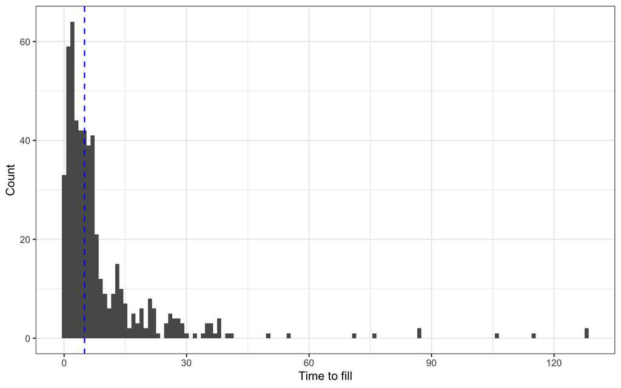

Figure 3.1: Histogram of time to fill. Median time (5 days) is shown by dashed blue line.

## 3.6 PMN Reasons

Referrals that were unfilled were reviewed for reasons for lack of fill and classified into reasons for not being filled. Reasons could have been either true, defined as no fill where a fill should have occurred, or “unknown fill outcome”, defined as an inability to confirm whether the referral was ultimately filled or not due to the referral being transferred to alternative filling methods.

| **Characteristic** | **N** | **N = 947**<sup>1</sup> |
| --- | --- | --- |
| Initial PMN designation | 947 |  |
| Filled, not PMN |  | 532 (56.2%) |
| Possible PMN |  | 415 (43.8%) |
| Final PMN designation | 947 |  |
| Filled, not PMN |  | 532 (56.2%) |
| True PMN |  | 69 (7.29%) |
| Unknown fill outcome |  | 346 (36.5%) |
| True PMN reason | 69 |  |
| Clinical decline |  | 8 (11.6%) |
| Death |  | 8 (11.6%) |
| Intentional delay of treatment initiation based on provider or patient request |  | 9 (13.0%) |
| Medication changed |  | 8 (11.6%) |
| Medication no longer clinically appropriate due to new or pending clinical data availability |  | 5 (7.25%) |
| Not approved on insurance |  | 9 (13.0%) |
| Patient decision |  | 17 (24.6%) |
| Unaffordable copay |  | 5 (7.25%) |
| Reason for unkown PMN status | 346 |  |
| Clinical trial medication fill |  | 1 (0.29%) |
| Inpatient fill |  | 2 (0.58%) |
| Manufacturer fill/PAP/sample |  | 98 (28.3%) |
| Rerouted to external SP (not previously captured) |  | 194 (56.1%) |
| Rx received for Benefits Investigation only |  | 51 (14.7%) |
| Unadjusted PMN rate | 947 |  |
| Not PMN |  | 878 (92.7%) |
| PMN |  | 69 (7.29%) |
| Adjusted PMN rate | 601 |  |
| Filled, not PMN |  | 532 (88.5%) |
| True PMN |  | 69 (11.5%) |

<sup>1</sup> n (%)

## 3.7 Rerouted to external SP

| **Characteristic** | **N** | **Site 1**, N = 69<sup>1</sup> | **Site 2**, N = 1<sup>1</sup> | **Site 3**, N = 105<sup>1</sup> | **Site 4**, N = 7<sup>1</sup> | **Site 5**, N = 6<sup>1</sup> | **Site 6**, N = 1<sup>1</sup> | **Site 7**, N = 5<sup>1</sup> | **Overall**, N = 194<sup>1</sup> |
| --- | --- | --- | --- | --- | --- | --- | --- | --- | --- |
| Why was the prescription re-routed to an external SP? | 193 |  |  |  |  |  |  |  |  |
| DRUG not in network (LDD) |  | 1 (1.45%) | 0 (0%) | 2 (1.92%) | 0 (0%) | 1 (16.7%) | 0 (0%) | 0 (0%) | 4 (2.07%) |
| PATIENT not in network (payer lockout) |  | 68 (98.6%) | 1 (100.0%) | 83 (79.8%) | 7 (100.0%) | 5 (83.3%) | 1 (100.0%) | 2 (40.0%) | 167 (86.5%) |
| Patient choice |  | 0 (0%) | 0 (0%) | 18 (17.3%) | 0 (0%) | 0 (0%) | 0 (0%) | 3 (60.0%) | 21 (10.9%) |
| Unknown |  | 0 (0%) | 0 (0%) | 1 (0.96%) | 0 (0%) | 0 (0%) | 0 (0%) | 0 (0%) | 1 (0.52%) |
| Missing |  | 0 | 0 | 1 | 0 | 0 | 0 | 0 | 1 |

<sup>1</sup> n (%)

# 4 Figures

## 4.1 Oral Oncolytic/PMN relationship

### 4.1.1 Count

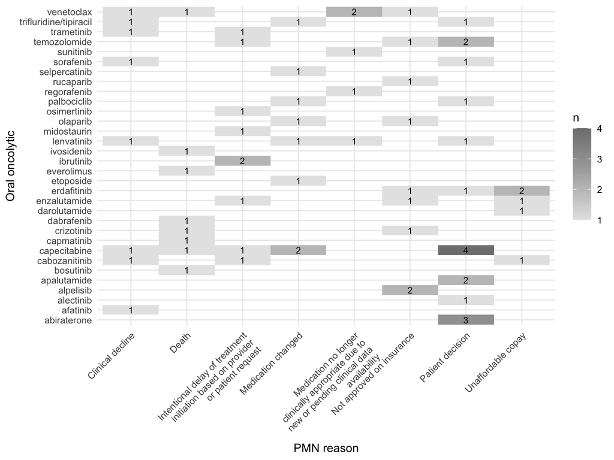

### 4.1.2 Fraction of individual medications

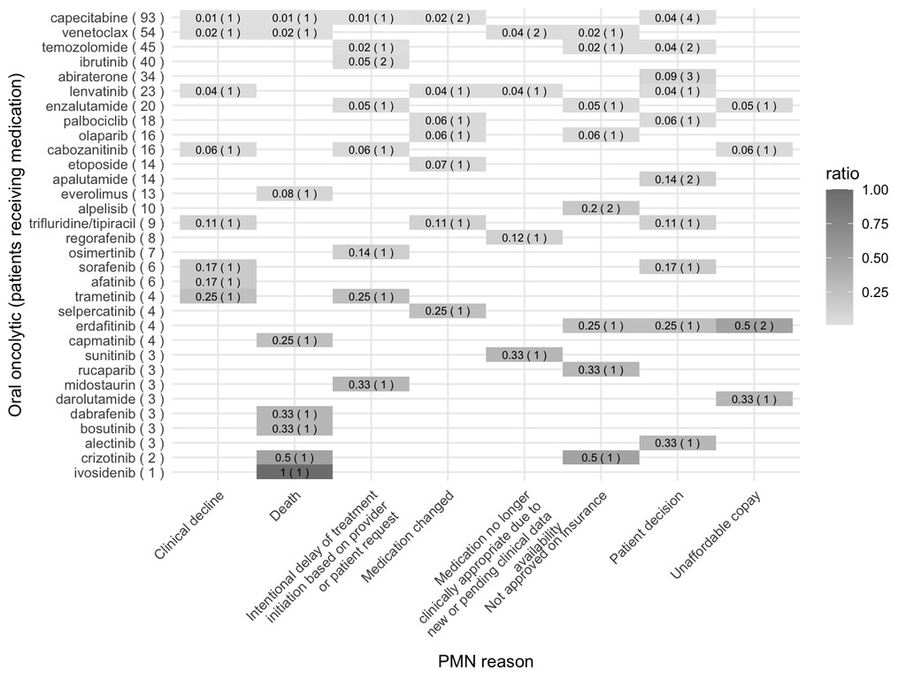